# Assessing soil fauna activity from in-situ imaging: influence of image capture resolution and frequency

This study investigates the influence of image capture resolution and frequency on the assessment of soil fauna activity. Three taxonomic groups were targeted: Enchytraeidae, Acari, and Collembola. Eight combinations of resolution and frequency were tested under controlled laboratory conditions.

## Materiel and method

**Experimental Setup** / Three plastic soil microcosms (40 × 40 × 20 cm) were placed in a greenhouse to allow controlled access and protection from rainfall. Opaque covers minimized light penetration, reproducing field-like conditions. Soil was collected from an experimental agroforestry site (DIAMS, Mauguio, France), sieved (2 cm and 2 mm) and positioned against scanner glass to standardize image composition. Vegetation was removed to ensure homogeneous soil composition.

Three Epson Perfection V39 scanners were angled at 45° to prevent soil displacement during irrigation. Each microcosm included temperature and moisture probes to monitor and maintain suitable conditions. Scanners were automated to capture images at predefined resolutions and frequencies.

**Capture Parameters**

- Resolutions: 600 dpi (minimum for smallest organisms), 1200 dpi (intermediate), 2400 dpi (maximum manageable file size).
- Frequencies: 15 min, 1 h, 6 h. Due to scanning duration, the 2400 dpi × 15 min combination was not feasible.

Eight combinations were tested: 600 dpi × 15 min, 1 h, 6 h; 1200 dpi × 15 min, 1 h, 6 h; 2400 dpi × 1 h, 6 h.

**Data collection** / Twelve images per combination per microcosm were captured to ensure balanced data. Low-frequency combinations required multiple days, while high-frequency combinations completed within hours. Three microcosms served as pseudo-replicates. Each combination was tested at different times of day to minimize diurnal effects. The cycle was repeated four times.

Images were analyzed with an automated invertebrate detection tool developed at UMR Eco&Sols using RStudio. The software segmented images into sub-images to detect moving objects, including soil fauna. High-resolution images (2400 dpi) were split into four sub-images for processing, resulting in 48 images per series.

Detected invertebrates were classified at the class or order level using an RStudio annotation script, producing structured datasets for statistical analysis.

## Results

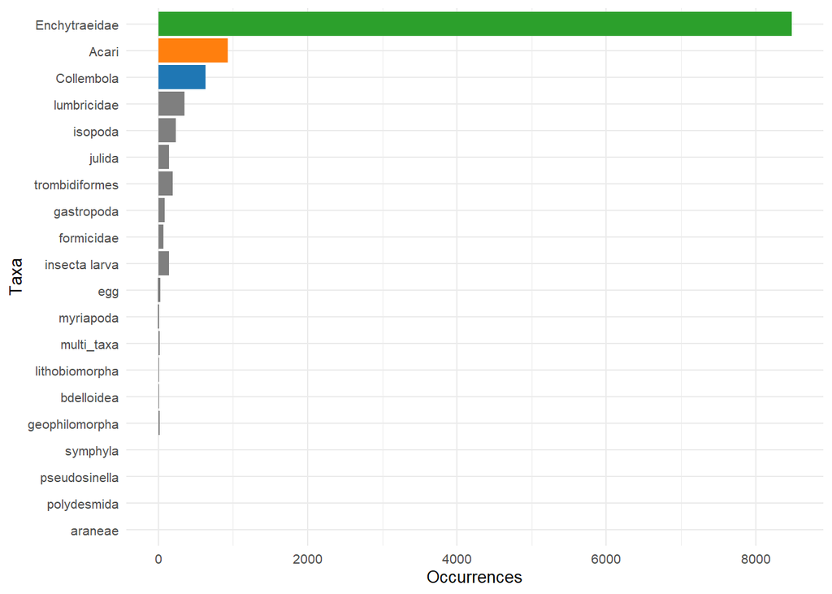

### Effect of capture resolution and frequency on overall fauna detection

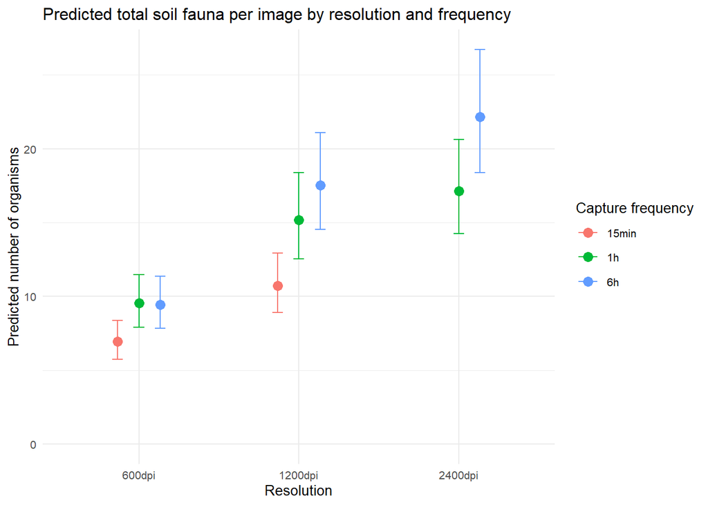

Higher resolution and moderate-to-long intervals between captures improve overall detection. Extremely high frequency at high resolution may not further increase detectability due to behavioral avoidance and technical limitations.

### Distribution of taxonomic groups across resolution and frequency

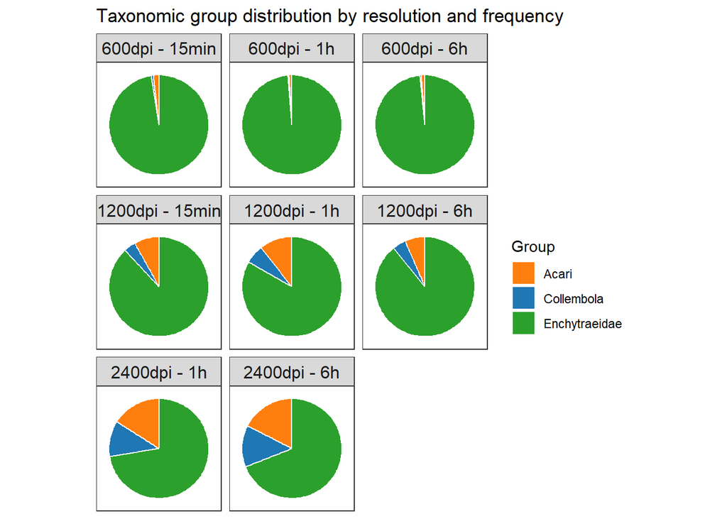

- Enchytraeidae were abundant across all modalities, with the maximum at 2400 dpi × 6 h (1,859 detections).
- Collembola were rarely detected at 600 dpi (4 detections) but increasingly at 1200 dpi (40–82) and 2400 dpi (182–251).
- Acari detections similarly increased with resolution: 10–11 at 600 dpi, 83–122 at 1200 dpi, and 251–325 at 2400 dpi.

Resolution critically affects detection of smaller taxa. Low-resolution scans fail to capture Collembola and Acari effectively.

### Enchytraeidae detection per image

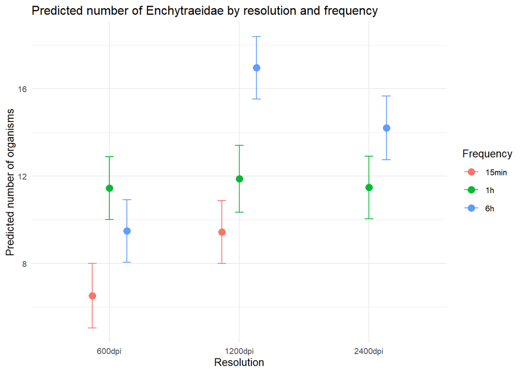

- 600 dpi: higher counts at 1 h and 6 h than 15 min (p < 0.05).
- 1200 dpi x 6 h frequency produced the highest counts (~17 per image).
- 2400 dpi: 6 h frequency slightly decreased counts compared to 1200 dpi.

Enchytraeidae may respond to repeated short-interval light exposure (lucifuge behavior), reducing detection at high-frequency captures. Longer intervals allow individuals to re-enter the scanned area.

### Collembola detection per image

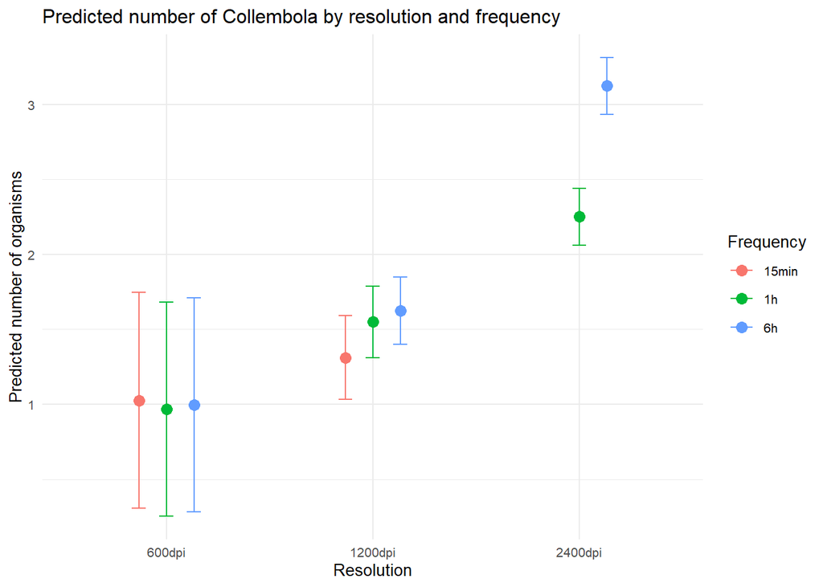

- 1200 dpi did not significantly increase detections over 600 dpi for any frequency.
- 2400 dpi increased detections >2 per image at 1 h and >3 per image at 6 h.
- Maximum detection at 2400 dpi × 6 h (p < 0.05).

Small size and light-sensitive behavior make Collembola detection highly dependent on resolution and less frequent imaging.

### Acari detection per image

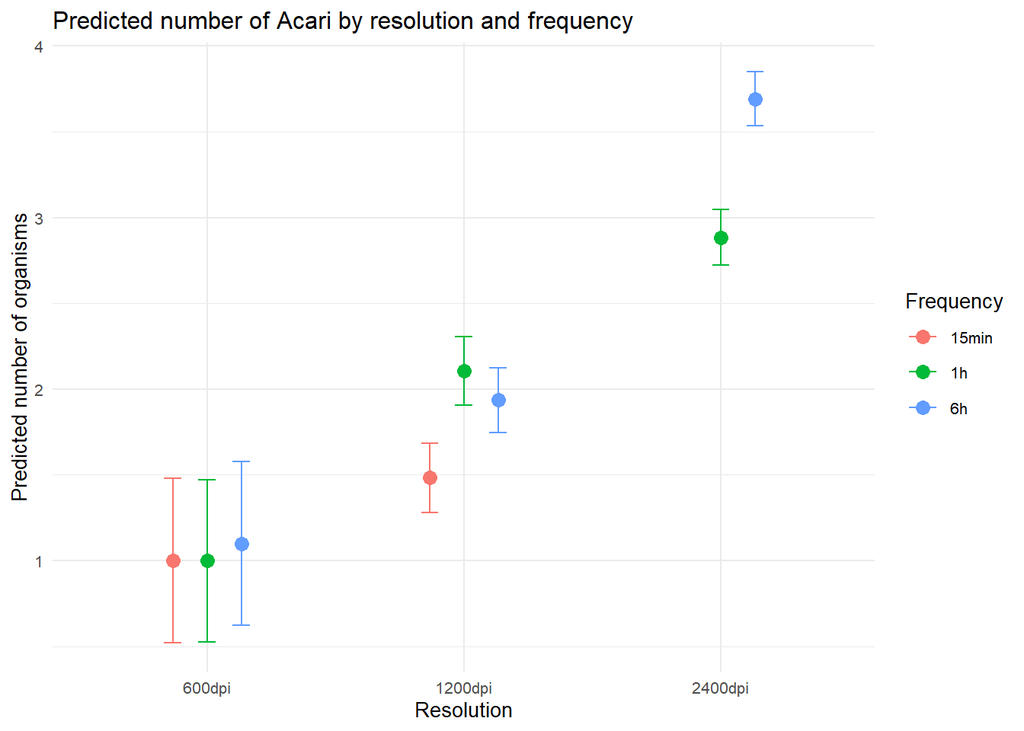

- 600 dpi: frequency had no effect.
- 1200 dpi: 1 h and 6 h increased detections (2 per image).
- 2400 dpi: 1 h and 6 h detected 3–4 individuals per image.

High resolution is essential for detecting Acari (<1 mm). Short-interval captures may reduce detection due to disturbance or light avoidance.